# Risk Factor Analysis

## Outcome Variable

**Outcome Variable:** ever_stunted

## Predictor Variables

**Intervention Variable:** vagbrth

**Adjustment Set:**

unadjusted

## Stratifying Variables

The analysis was stratified on these variable(s):

- agecat
- studyid
- country

## Data Summary

| agecat | studyid | country | A | n | nA | nAY0 | nAY1 |
| --- | --- | --- | --- | --- | --- | --- | --- |
| 3 months | ki1000108-CMC-V-BCS-2002 | INDIA | 0 | 362 | 25 | 16 | 9 |
| 3 months | ki1000108-CMC-V-BCS-2002 | INDIA | 1 | 362 | 337 | 221 | 116 |
| 3 months | ki1000108-IRC | INDIA | 0 | 410 | 70 | 43 | 27 |
| 3 months | ki1000108-IRC | INDIA | 1 | 410 | 340 | 237 | 103 |
| 3 months | ki1017093b-PROVIDE | BANGLADESH | 0 | 700 | 160 | 133 | 27 |
| 3 months | ki1017093b-PROVIDE | BANGLADESH | 1 | 700 | 540 | 437 | 103 |
| 3 months | ki1017093c-NIH-Crypto | BANGLADESH | 0 | 500 | 204 | 171 | 33 |
| 3 months | ki1017093c-NIH-Crypto | BANGLADESH | 1 | 500 | 296 | 245 | 51 |
| 3 months | ki1066203-TanzaniaChild2 | TANZANIA, UNITED REPUBLIC OF | 0 | 2364 | 212 | 186 | 26 |
| 3 months | ki1066203-TanzaniaChild2 | TANZANIA, UNITED REPUBLIC OF | 1 | 2364 | 2152 | 1935 | 217 |
| 3 months | ki1119695-PROBIT | BELARUS | 0 | 8125 | 849 | 771 | 78 |
| 3 months | ki1119695-PROBIT | BELARUS | 1 | 8125 | 7276 | 6752 | 524 |
| 3 months | ki1126311-ZVITAMBO | ZIMBABWE | 0 | 13917 | 1176 | 949 | 227 |
| 3 months | ki1126311-ZVITAMBO | ZIMBABWE | 1 | 13917 | 12741 | 10059 | 2682 |
| 3 months | kiGH5241-JiVitA-3 | BANGLADESH | 0 | 13327 | 735 | 540 | 195 |
| 3 months | kiGH5241-JiVitA-3 | BANGLADESH | 1 | 13327 | 12592 | 7416 | 5176 |
| 3 months | kiGH5241-JiVitA-4 | BANGLADESH | 0 | 1155 | 72 | 55 | 17 |
| 3 months | kiGH5241-JiVitA-4 | BANGLADESH | 1 | 1155 | 1083 | 785 | 298 |
| 6 months | ki1000108-CMC-V-BCS-2002 | INDIA | 0 | 367 | 25 | 12 | 13 |
| 6 months | ki1000108-CMC-V-BCS-2002 | INDIA | 1 | 367 | 342 | 167 | 175 |
| 6 months | ki1000108-IRC | INDIA | 0 | 408 | 70 | 35 | 35 |
| 6 months | ki1000108-IRC | INDIA | 1 | 408 | 338 | 200 | 138 |
| 6 months | ki1017093b-PROVIDE | BANGLADESH | 0 | 640 | 147 | 114 | 33 |
| 6 months | ki1017093b-PROVIDE | BANGLADESH | 1 | 640 | 493 | 363 | 130 |
| 6 months | ki1017093c-NIH-Crypto | BANGLADESH | 0 | 478 | 196 | 140 | 56 |
| 6 months | ki1017093c-NIH-Crypto | BANGLADESH | 1 | 478 | 282 | 189 | 93 |
| 6 months | ki1066203-TanzaniaChild2 | TANZANIA, UNITED REPUBLIC OF | 0 | 2207 | 203 | 160 | 43 |
| 6 months | ki1066203-TanzaniaChild2 | TANZANIA, UNITED REPUBLIC OF | 1 | 2207 | 2004 | 1602 | 402 |
| 6 months | ki1119695-PROBIT | BELARUS | 0 | 7807 | 815 | 718 | 97 |
| 6 months | ki1119695-PROBIT | BELARUS | 1 | 7807 | 6992 | 6275 | 717 |

[output cut: 60 more lines]

The following strata were considered:

- agecat: 12 months, studyid: ki1000108-CMC-V-BCS-2002, country: INDIA
- agecat: 12 months, studyid: ki1000108-IRC, country: INDIA
- agecat: 12 months, studyid: ki1017093b-PROVIDE, country: BANGLADESH
- agecat: 12 months, studyid: ki1017093c-NIH-Crypto, country: BANGLADESH
- agecat: 12 months, studyid: ki1066203-TanzaniaChild2, country: TANZANIA, UNITED REPUBLIC OF
- agecat: 12 months, studyid: ki1119695-PROBIT, country: BELARUS
- agecat: 12 months, studyid: ki1126311-ZVITAMBO, country: ZIMBABWE
- agecat: 12 months, studyid: kiGH5241-JiVitA-3, country: BANGLADESH
- agecat: 12 months, studyid: kiGH5241-JiVitA-4, country: BANGLADESH
- agecat: 18 months, studyid: ki1000108-CMC-V-BCS-2002, country: INDIA
- agecat: 18 months, studyid: ki1000108-IRC, country: INDIA
- agecat: 18 months, studyid: ki1017093b-PROVIDE, country: BANGLADESH
- agecat: 18 months, studyid: ki1017093c-NIH-Crypto, country: BANGLADESH
- agecat: 18 months, studyid: ki1066203-TanzaniaChild2, country: TANZANIA, UNITED REPUBLIC OF
- agecat: 18 months, studyid: ki1119695-PROBIT, country: BELARUS
- agecat: 18 months, studyid: ki1126311-ZVITAMBO, country: ZIMBABWE
- agecat: 18 months, studyid: kiGH5241-JiVitA-3, country: BANGLADESH
- agecat: 18 months, studyid: kiGH5241-JiVitA-4, country: BANGLADESH
- agecat: 24 months, studyid: ki1000108-CMC-V-BCS-2002, country: INDIA
- agecat: 24 months, studyid: ki1000108-IRC, country: INDIA
- agecat: 24 months, studyid: ki1017093b-PROVIDE, country: BANGLADESH
- agecat: 24 months, studyid: ki1017093c-NIH-Crypto, country: BANGLADESH
- agecat: 24 months, studyid: ki1066203-TanzaniaChild2, country: TANZANIA, UNITED REPUBLIC OF
- agecat: 24 months, studyid: ki1119695-PROBIT, country: BELARUS
- agecat: 24 months, studyid: ki1126311-ZVITAMBO, country: ZIMBABWE
- agecat: 24 months, studyid: kiGH5241-JiVitA-3, country: BANGLADESH
- agecat: 24 months, studyid: kiGH5241-JiVitA-4, country: BANGLADESH
- agecat: 3 months, studyid: ki1000108-CMC-V-BCS-2002, country: INDIA
- agecat: 3 months, studyid: ki1000108-IRC, country: INDIA
- agecat: 3 months, studyid: ki1017093b-PROVIDE, country: BANGLADESH
- agecat: 3 months, studyid: ki1017093c-NIH-Crypto, country: BANGLADESH
- agecat: 3 months, studyid: ki1066203-TanzaniaChild2, country: TANZANIA, UNITED REPUBLIC OF
- agecat: 3 months, studyid: ki1119695-PROBIT, country: BELARUS
- agecat: 3 months, studyid: ki1126311-ZVITAMBO, country: ZIMBABWE
- agecat: 3 months, studyid: kiGH5241-JiVitA-3, country: BANGLADESH
- agecat: 3 months, studyid: kiGH5241-JiVitA-4, country: BANGLADESH
- agecat: 6 months, studyid: ki1000108-CMC-V-BCS-2002, country: INDIA
- agecat: 6 months, studyid: ki1000108-IRC, country: INDIA
- agecat: 6 months, studyid: ki1017093b-PROVIDE, country: BANGLADESH
- agecat: 6 months, studyid: ki1017093c-NIH-Crypto, country: BANGLADESH
- agecat: 6 months, studyid: ki1066203-TanzaniaChild2, country: TANZANIA, UNITED REPUBLIC OF
- agecat: 6 months, studyid: ki1119695-PROBIT, country: BELARUS
- agecat: 6 months, studyid: ki1126311-ZVITAMBO, country: ZIMBABWE
- agecat: 6 months, studyid: kiGH5241-JiVitA-3, country: BANGLADESH
- agecat: 6 months, studyid: kiGH5241-JiVitA-4, country: BANGLADESH

### Dropped Strata

Some strata were dropped due to rare outcomes:

- agecat: 18 months, studyid: ki1000108-CMC-V-BCS-2002, country: INDIA
- agecat: 24 months, studyid: ki1000108-CMC-V-BCS-2002, country: INDIA
- agecat: 24 months, studyid: kiGH5241-JiVitA-3, country: BANGLADESH

## Methods Detail

We’re interested in the causal parameters $E[Y_a]$ for all values of $a \in \mathcal{A}$. These parameters represent the mean outcome if, possibly contrary to fact, we intervened to set all units to have $A=a$. Under the randomization and positivity assumptions, these are identified by the statistical parameters $\psi_a=E_W[E_{Y|A,W}(Y|A=a,W)]$. In addition, we’re interested in the mean of $Y$, $E[Y]$ under no intervention (the observed mean). We will estimate these parameters by using SuperLearner to fit the relevant likelihood factors – $E_{Y|A,W}(Y|A=a,W)$ and $p(A=a|W)$, and then updating our likelihood fit using a joint TMLE.

For unadjusted analyses ($W=\{\}$), initial likelihoods were estimated using Lrnr_glm to estimate the simple $E(Y|A)$ and Lrnr_mean to estimate $p(A)$. For adjusted analyses, a small library containing Lrnr_glmnet, Lrnr_xgboost, and Lrnr_mean was used.

Having estimated these parameters, we will then use the delta method to estimate relative risks and attributable risks relative to a prespecified baseline level of $A$.

# Results Detail

## Results Plots

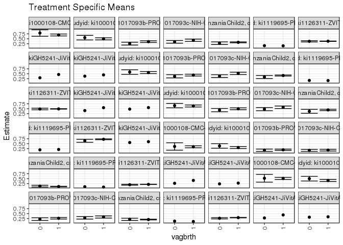

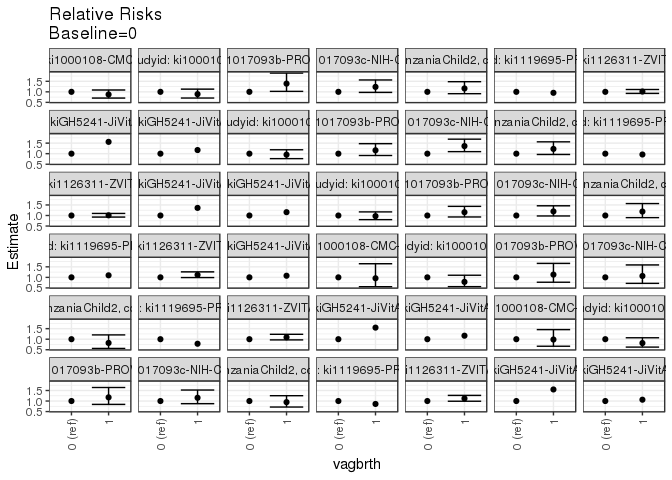

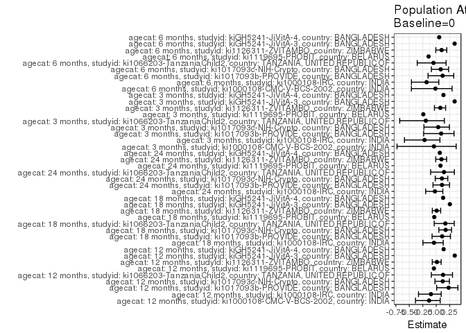

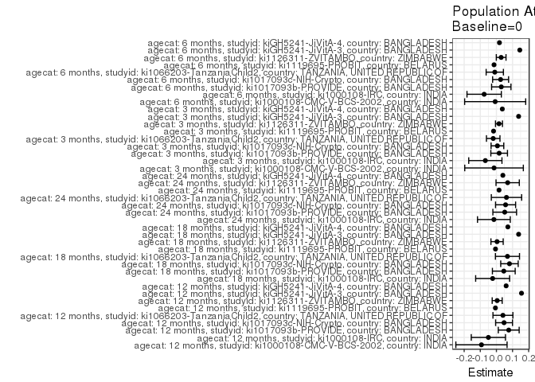

## Results Table

### Parameter: TSM

| agecat | studyid | country | intervention_level | baseline_level | estimate | ci_lower | ci_upper |
| --- | --- | --- | --- | --- | --- | --- | --- |
| 3 months | ki1000108-CMC-V-BCS-2002 | INDIA | 0 | NA | 0.3600000 | 0.1715830 | 0.5484170 |
| 3 months | ki1000108-CMC-V-BCS-2002 | INDIA | 1 | NA | 0.3442136 | 0.2934177 | 0.3950096 |
| 3 months | ki1000108-IRC | INDIA | 0 | NA | 0.3857143 | 0.2715455 | 0.4998831 |
| 3 months | ki1000108-IRC | INDIA | 1 | NA | 0.3029412 | 0.2540362 | 0.3518461 |
| 3 months | ki1017093b-PROVIDE | BANGLADESH | 0 | NA | 0.1687500 | 0.1106754 | 0.2268246 |
| 3 months | ki1017093b-PROVIDE | BANGLADESH | 1 | NA | 0.1907407 | 0.1575798 | 0.2239017 |
| 3 months | ki1017093c-NIH-Crypto | BANGLADESH | 0 | NA | 0.1617647 | 0.1111831 | 0.2123463 |
| 3 months | ki1017093c-NIH-Crypto | BANGLADESH | 1 | NA | 0.1722973 | 0.1292334 | 0.2153612 |
| 3 months | ki1066203-TanzaniaChild2 | TANZANIA, UNITED REPUBLIC OF | 0 | NA | 0.1226415 | 0.0784764 | 0.1668066 |
| 3 months | ki1066203-TanzaniaChild2 | TANZANIA, UNITED REPUBLIC OF | 1 | NA | 0.1008364 | 0.0881118 | 0.1135611 |
| 3 months | ki1119695-PROBIT | BELARUS | 0 | NA | 0.0918728 | NA | NA |
| 3 months | ki1119695-PROBIT | BELARUS | 1 | NA | 0.0720176 | NA | NA |
| 3 months | ki1126311-ZVITAMBO | ZIMBABWE | 0 | NA | 0.1930272 | 0.1704693 | 0.2155851 |
| 3 months | ki1126311-ZVITAMBO | ZIMBABWE | 1 | NA | 0.2105015 | 0.2034226 | 0.2175804 |
| 3 months | kiGH5241-JiVitA-3 | BANGLADESH | 0 | NA | 0.2653061 | NA | NA |
| 3 months | kiGH5241-JiVitA-3 | BANGLADESH | 1 | NA | 0.4110546 | NA | NA |
| 3 months | kiGH5241-JiVitA-4 | BANGLADESH | 0 | NA | 0.2361111 | NA | NA |
| 3 months | kiGH5241-JiVitA-4 | BANGLADESH | 1 | NA | 0.2751616 | NA | NA |
| 6 months | ki1000108-CMC-V-BCS-2002 | INDIA | 0 | NA | 0.5200000 | 0.3238931 | 0.7161069 |
| 6 months | ki1000108-CMC-V-BCS-2002 | INDIA | 1 | NA | 0.5116959 | 0.4586467 | 0.5647451 |
| 6 months | ki1000108-IRC | INDIA | 0 | NA | 0.5000000 | 0.3827259 | 0.6172741 |
| 6 months | ki1000108-IRC | INDIA | 1 | NA | 0.4082840 | 0.3558201 | 0.4607479 |
| 6 months | ki1017093b-PROVIDE | BANGLADESH | 0 | NA | 0.2244898 | 0.1569871 | 0.2919925 |
| 6 months | ki1017093b-PROVIDE | BANGLADESH | 1 | NA | 0.2636917 | 0.2247655 | 0.3026179 |
| 6 months | ki1017093c-NIH-Crypto | BANGLADESH | 0 | NA | 0.2857143 | 0.2224036 | 0.3490249 |
| 6 months | ki1017093c-NIH-Crypto | BANGLADESH | 1 | NA | 0.3297872 | 0.2748583 | 0.3847162 |
| 6 months | ki1066203-TanzaniaChild2 | TANZANIA, UNITED REPUBLIC OF | 0 | NA | 0.2118227 | 0.1556019 | 0.2680434 |
| 6 months | ki1066203-TanzaniaChild2 | TANZANIA, UNITED REPUBLIC OF | 1 | NA | 0.2005988 | 0.1830623 | 0.2181354 |
| 6 months | ki1119695-PROBIT | BELARUS | 0 | NA | 0.1190184 | NA | NA |
| 6 months | ki1119695-PROBIT | BELARUS | 1 | NA | 0.1025458 | NA | NA |

[output cut: 54 more lines]

### Parameter: E(Y)

| agecat | studyid | country | intervention_level | baseline_level | estimate | ci_lower | ci_upper |
| --- | --- | --- | --- | --- | --- | --- | --- |
| 3 months | ki1000108-CMC-V-BCS-2002 | INDIA | NA | NA | 0.3453039 | 0.2962566 | 0.3943512 |
| 3 months | ki1000108-IRC | INDIA | NA | NA | 0.3170732 | 0.2719756 | 0.3621708 |
| 3 months | ki1017093b-PROVIDE | BANGLADESH | NA | NA | 0.1857143 | 0.1568859 | 0.2145427 |
| 3 months | ki1017093c-NIH-Crypto | BANGLADESH | NA | NA | 0.1680000 | 0.1351970 | 0.2008030 |
| 3 months | ki1066203-TanzaniaChild2 | TANZANIA, UNITED REPUBLIC OF | NA | NA | 0.1027919 | 0.0905473 | 0.1150364 |
| 3 months | ki1119695-PROBIT | BELARUS | NA | NA | 0.0740923 | NA | NA |
| 3 months | ki1126311-ZVITAMBO | ZIMBABWE | NA | NA | 0.2090249 | 0.2022692 | 0.2157806 |
| 3 months | kiGH5241-JiVitA-3 | BANGLADESH | NA | NA | 0.4030164 | NA | NA |
| 3 months | kiGH5241-JiVitA-4 | BANGLADESH | NA | NA | 0.2727273 | NA | NA |
| 6 months | ki1000108-CMC-V-BCS-2002 | INDIA | NA | NA | 0.5122616 | 0.4610525 | 0.5634707 |
| 6 months | ki1000108-IRC | INDIA | NA | NA | 0.4240196 | 0.3760078 | 0.4720314 |
| 6 months | ki1017093b-PROVIDE | BANGLADESH | NA | NA | 0.2546875 | 0.2209066 | 0.2884684 |
| 6 months | ki1017093c-NIH-Crypto | BANGLADESH | NA | NA | 0.3117155 | 0.2701482 | 0.3532828 |
| 6 months | ki1066203-TanzaniaChild2 | TANZANIA, UNITED REPUBLIC OF | NA | NA | 0.2016312 | 0.1848885 | 0.2183739 |
| 6 months | ki1119695-PROBIT | BELARUS | NA | NA | 0.1042654 | NA | NA |
| 6 months | ki1126311-ZVITAMBO | ZIMBABWE | NA | NA | 0.2945213 | 0.2851217 | 0.3039209 |
| 6 months | kiGH5241-JiVitA-3 | BANGLADESH | NA | NA | 0.4250026 | NA | NA |
| 6 months | kiGH5241-JiVitA-4 | BANGLADESH | NA | NA | 0.3382209 | NA | NA |
| 12 months | ki1000108-CMC-V-BCS-2002 | INDIA | NA | NA | 0.6989247 | 0.6522466 | 0.7456029 |
| 12 months | ki1000108-IRC | INDIA | NA | NA | 0.5073529 | 0.4587823 | 0.5559236 |
| 12 months | ki1017093b-PROVIDE | BANGLADESH | NA | NA | 0.3316913 | 0.2942672 | 0.3691154 |
| 12 months | ki1017093c-NIH-Crypto | BANGLADESH | NA | NA | 0.3927813 | 0.3486296 | 0.4369330 |
| 12 months | ki1066203-TanzaniaChild2 | TANZANIA, UNITED REPUBLIC OF | NA | NA | 0.3176292 | 0.2970866 | 0.3381718 |
| 12 months | ki1119695-PROBIT | BELARUS | NA | NA | 0.1456628 | NA | NA |
| 12 months | ki1126311-ZVITAMBO | ZIMBABWE | NA | NA | 0.3767083 | 0.3672568 | 0.3861597 |
| 12 months | kiGH5241-JiVitA-3 | BANGLADESH | NA | NA | 0.4520384 | NA | NA |
| 12 months | kiGH5241-JiVitA-4 | BANGLADESH | NA | NA | 0.4384027 | NA | NA |
| 18 months | ki1000108-IRC | INDIA | NA | NA | 0.5623472 | 0.5142095 | 0.6104849 |
| 18 months | ki1017093b-PROVIDE | BANGLADESH | NA | NA | 0.4172185 | 0.3778614 | 0.4565757 |
| 18 months | ki1017093c-NIH-Crypto | BANGLADESH | NA | NA | 0.4618736 | 0.4162154 | 0.5075319 |
| 18 months | ki1066203-TanzaniaChild2 | TANZANIA, UNITED REPUBLIC OF | NA | NA | 0.4041812 | 0.3787821 | 0.4295803 |
| 18 months | ki1119695-PROBIT | BELARUS | NA | NA | 0.1565217 | NA | NA |
| 18 months | ki1126311-ZVITAMBO | ZIMBABWE | NA | NA | 0.4900360 | 0.4785091 | 0.5015629 |
| 18 months | kiGH5241-JiVitA-3 | BANGLADESH | NA | NA | 0.5435736 | NA | NA |
| 18 months | kiGH5241-JiVitA-4 | BANGLADESH | NA | NA | 0.5519651 | NA | NA |
| 24 months | ki1000108-IRC | INDIA | NA | NA | 0.6414634 | 0.5949863 | 0.6879405 |
| 24 months | ki1017093b-PROVIDE | BANGLADESH | NA | NA | 0.4810997 | 0.4404722 | 0.5217271 |
| 24 months | ki1017093c-NIH-Crypto | BANGLADESH | NA | NA | 0.5368421 | 0.4866406 | 0.5870436 |
| 24 months | ki1066203-TanzaniaChild2 | TANZANIA, UNITED REPUBLIC OF | NA | NA | 0.4320337 | 0.4005008 | 0.4635666 |
| 24 months | ki1119695-PROBIT | BELARUS | NA | NA | 0.2061657 | NA | NA |
| 24 months | ki1126311-ZVITAMBO | ZIMBABWE | NA | NA | 0.7168189 | 0.6963437 | 0.7372941 |
| 24 months | kiGH5241-JiVitA-4 | BANGLADESH | NA | NA | 0.5988083 | NA | NA |

### Parameter: RR

| agecat | studyid | country | intervention_level | baseline_level | estimate | ci_lower | ci_upper |
| --- | --- | --- | --- | --- | --- | --- | --- |
| 3 months | ki1000108-CMC-V-BCS-2002 | INDIA | 0 | 0 | 1.0000000 | 1.0000000 | 1.000000 |
| 3 months | ki1000108-CMC-V-BCS-2002 | INDIA | 1 | 0 | 0.9561490 | 0.5550881 | 1.646984 |
| 3 months | ki1000108-IRC | INDIA | 0 | 0 | 1.0000000 | 1.0000000 | 1.000000 |
| 3 months | ki1000108-IRC | INDIA | 1 | 0 | 0.7854031 | 0.5606198 | 1.100314 |
| 3 months | ki1017093b-PROVIDE | BANGLADESH | 0 | 0 | 1.0000000 | 1.0000000 | 1.000000 |
| 3 months | ki1017093b-PROVIDE | BANGLADESH | 1 | 0 | 1.1303155 | 0.7686884 | 1.662069 |
| 3 months | ki1017093c-NIH-Crypto | BANGLADESH | 0 | 0 | 1.0000000 | 1.0000000 | 1.000000 |
| 3 months | ki1017093c-NIH-Crypto | BANGLADESH | 1 | 0 | 1.0651106 | 0.7137487 | 1.589440 |
| 3 months | ki1066203-TanzaniaChild2 | TANZANIA, UNITED REPUBLIC OF | 0 | 0 | 1.0000000 | 1.0000000 | 1.000000 |
| 3 months | ki1066203-TanzaniaChild2 | TANZANIA, UNITED REPUBLIC OF | 1 | 0 | 0.8222048 | 0.5613834 | 1.204205 |
| 3 months | ki1119695-PROBIT | BELARUS | 0 | 0 | 1.0000000 | NA | NA |
| 3 months | ki1119695-PROBIT | BELARUS | 1 | 0 | 0.7838838 | NA | NA |
| 3 months | ki1126311-ZVITAMBO | ZIMBABWE | 0 | 0 | 1.0000000 | 1.0000000 | 1.000000 |
| 3 months | ki1126311-ZVITAMBO | ZIMBABWE | 1 | 0 | 1.0905278 | 0.9656591 | 1.231543 |
| 3 months | kiGH5241-JiVitA-3 | BANGLADESH | 0 | 0 | 1.0000000 | NA | NA |
| 3 months | kiGH5241-JiVitA-3 | BANGLADESH | 1 | 0 | 1.5493598 | NA | NA |
| 3 months | kiGH5241-JiVitA-4 | BANGLADESH | 0 | 0 | 1.0000000 | NA | NA |
| 3 months | kiGH5241-JiVitA-4 | BANGLADESH | 1 | 0 | 1.1653903 | NA | NA |
| 6 months | ki1000108-CMC-V-BCS-2002 | INDIA | 0 | 0 | 1.0000000 | 1.0000000 | 1.000000 |
| 6 months | ki1000108-CMC-V-BCS-2002 | INDIA | 1 | 0 | 0.9840306 | 0.6654995 | 1.455022 |
| 6 months | ki1000108-IRC | INDIA | 0 | 0 | 1.0000000 | 1.0000000 | 1.000000 |
| 6 months | ki1000108-IRC | INDIA | 1 | 0 | 0.8165680 | 0.6249485 | 1.066941 |
| 6 months | ki1017093b-PROVIDE | BANGLADESH | 0 | 0 | 1.0000000 | 1.0000000 | 1.000000 |
| 6 months | ki1017093b-PROVIDE | BANGLADESH | 1 | 0 | 1.1746266 | 0.8402759 | 1.642017 |
| 6 months | ki1017093c-NIH-Crypto | BANGLADESH | 0 | 0 | 1.0000000 | 1.0000000 | 1.000000 |
| 6 months | ki1017093c-NIH-Crypto | BANGLADESH | 1 | 0 | 1.1542553 | 0.8748088 | 1.522967 |
| 6 months | ki1066203-TanzaniaChild2 | TANZANIA, UNITED REPUBLIC OF | 0 | 0 | 1.0000000 | 1.0000000 | 1.000000 |
| 6 months | ki1066203-TanzaniaChild2 | TANZANIA, UNITED REPUBLIC OF | 1 | 0 | 0.9470130 | 0.7161373 | 1.252321 |
| 6 months | ki1119695-PROBIT | BELARUS | 0 | 0 | 1.0000000 | NA | NA |
| 6 months | ki1119695-PROBIT | BELARUS | 1 | 0 | 0.8615959 | NA | NA |

[output cut: 54 more lines]

### Parameter: PAR

| agecat | studyid | country | intervention_level | baseline_level | estimate | ci_lower | ci_upper |
| --- | --- | --- | --- | --- | --- | --- | --- |
| 3 months | ki1000108-CMC-V-BCS-2002 | INDIA | 0 | NA | -0.0146961 | -0.1963638 | 0.1669715 |
| 3 months | ki1000108-IRC | INDIA | 0 | NA | -0.0686411 | -0.1716824 | 0.0344001 |
| 3 months | ki1017093b-PROVIDE | BANGLADESH | 0 | NA | 0.0169643 | -0.0346298 | 0.0685584 |
| 3 months | ki1017093c-NIH-Crypto | BANGLADESH | 0 | NA | 0.0062353 | -0.0330941 | 0.0455647 |
| 3 months | ki1066203-TanzaniaChild2 | TANZANIA, UNITED REPUBLIC OF | 0 | NA | -0.0198496 | -0.0616903 | 0.0219910 |
| 3 months | ki1119695-PROBIT | BELARUS | 0 | NA | -0.0177805 | NA | NA |
| 3 months | ki1126311-ZVITAMBO | ZIMBABWE | 0 | NA | 0.0159977 | -0.0056472 | 0.0376426 |
| 3 months | kiGH5241-JiVitA-3 | BANGLADESH | 0 | NA | 0.1377103 | NA | NA |
| 3 months | kiGH5241-JiVitA-4 | BANGLADESH | 0 | NA | 0.0366162 | NA | NA |
| 6 months | ki1000108-CMC-V-BCS-2002 | INDIA | 0 | NA | -0.0077384 | -0.1970550 | 0.1815782 |
| 6 months | ki1000108-IRC | INDIA | 0 | NA | -0.0759804 | -0.1824656 | 0.0305048 |
| 6 months | ki1017093b-PROVIDE | BANGLADESH | 0 | NA | 0.0301977 | -0.0298403 | 0.0902357 |
| 6 months | ki1017093c-NIH-Crypto | BANGLADESH | 0 | NA | 0.0260012 | -0.0234861 | 0.0754885 |
| 6 months | ki1066203-TanzaniaChild2 | TANZANIA, UNITED REPUBLIC OF | 0 | NA | -0.0101915 | -0.0636670 | 0.0432841 |
| 6 months | ki1119695-PROBIT | BELARUS | 0 | NA | -0.0147530 | NA | NA |
| 6 months | ki1126311-ZVITAMBO | ZIMBABWE | 0 | NA | 0.0294294 | -0.0006523 | 0.0595112 |
| 6 months | kiGH5241-JiVitA-3 | BANGLADESH | 0 | NA | 0.1450026 | NA | NA |
| 6 months | kiGH5241-JiVitA-4 | BANGLADESH | 0 | NA | 0.0187765 | NA | NA |
| 12 months | ki1000108-CMC-V-BCS-2002 | INDIA | 0 | NA | -0.0927419 | -0.2515923 | 0.0661084 |
| 12 months | ki1000108-IRC | INDIA | 0 | NA | -0.0497899 | -0.1559741 | 0.0563943 |
| 12 months | ki1017093b-PROVIDE | BANGLADESH | 0 | NA | 0.0763721 | 0.0116688 | 0.1410755 |
| 12 months | ki1017093c-NIH-Crypto | BANGLADESH | 0 | NA | 0.0474205 | -0.0049241 | 0.0997651 |
| 12 months | ki1066203-TanzaniaChild2 | TANZANIA, UNITED REPUBLIC OF | 0 | NA | 0.0404553 | -0.0214053 | 0.1023158 |
| 12 months | ki1119695-PROBIT | BELARUS | 0 | NA | -0.0063275 | NA | NA |
| 12 months | ki1126311-ZVITAMBO | ZIMBABWE | 0 | NA | 0.0047784 | -0.0262252 | 0.0357821 |
| 12 months | kiGH5241-JiVitA-3 | BANGLADESH | 0 | NA | 0.1556031 | NA | NA |
| 12 months | kiGH5241-JiVitA-4 | BANGLADESH | 0 | NA | 0.0603539 | NA | NA |
| 18 months | ki1000108-IRC | INDIA | 0 | NA | -0.0233671 | -0.1287087 | 0.0819745 |
| 18 months | ki1017093b-PROVIDE | BANGLADESH | 0 | NA | 0.0457900 | -0.0248578 | 0.1164377 |
| 18 months | ki1017093c-NIH-Crypto | BANGLADESH | 0 | NA | 0.0809213 | 0.0267697 | 0.1350728 |
| 18 months | ki1066203-TanzaniaChild2 | TANZANIA, UNITED REPUBLIC OF | 0 | NA | 0.0684669 | -0.0061906 | 0.1431244 |
| 18 months | ki1119695-PROBIT | BELARUS | 0 | NA | -0.0056749 | NA | NA |
| 18 months | ki1126311-ZVITAMBO | ZIMBABWE | 0 | NA | 0.0039933 | -0.0339959 | 0.0419824 |
| 18 months | kiGH5241-JiVitA-3 | BANGLADESH | 0 | NA | 0.1377440 | NA | NA |
| 18 months | kiGH5241-JiVitA-4 | BANGLADESH | 0 | NA | 0.0709524 | NA | NA |
| 24 months | ki1000108-IRC | INDIA | 0 | NA | -0.0156794 | -0.1172787 | 0.0859198 |
| 24 months | ki1017093b-PROVIDE | BANGLADESH | 0 | NA | 0.0514700 | -0.0219811 | 0.1249212 |
| 24 months | ki1017093c-NIH-Crypto | BANGLADESH | 0 | NA | 0.0568421 | -0.0053629 | 0.1190471 |
| 24 months | ki1066203-TanzaniaChild2 | TANZANIA, UNITED REPUBLIC OF | 0 | NA | 0.0624685 | -0.0315780 | 0.1565150 |
| 24 months | ki1119695-PROBIT | BELARUS | 0 | NA | 0.0162923 | NA | NA |
| 24 months | ki1126311-ZVITAMBO | ZIMBABWE | 0 | NA | 0.0697601 | -0.0024404 | 0.1419605 |
| 24 months | kiGH5241-JiVitA-4 | BANGLADESH | 0 | NA | 0.0399848 | NA | NA |

### Parameter: PAF

| agecat | studyid | country | intervention_level | baseline_level | estimate | ci_lower | ci_upper |
| --- | --- | --- | --- | --- | --- | --- | --- |
| 3 months | ki1000108-CMC-V-BCS-2002 | INDIA | 0 | NA | -0.0425600 | -0.7268777 | 0.3705800 |
| 3 months | ki1000108-IRC | INDIA | 0 | NA | -0.2164835 | -0.5892522 | 0.0688501 |
| 3 months | ki1017093b-PROVIDE | BANGLADESH | 0 | NA | 0.0913462 | -0.2333307 | 0.3305511 |
| 3 months | ki1017093c-NIH-Crypto | BANGLADESH | 0 | NA | 0.0371149 | -0.2278135 | 0.2448790 |
| 3 months | ki1066203-TanzaniaChild2 | TANZANIA, UNITED REPUBLIC OF | 0 | NA | -0.1931050 | -0.6775347 | 0.1514336 |
| 3 months | ki1119695-PROBIT | BELARUS | 0 | NA | -0.2399775 | NA | NA |
| 3 months | ki1126311-ZVITAMBO | ZIMBABWE | 0 | NA | 0.0765350 | -0.0330288 | 0.1744784 |
| 3 months | kiGH5241-JiVitA-3 | BANGLADESH | 0 | NA | 0.3416990 | NA | NA |
| 3 months | kiGH5241-JiVitA-4 | BANGLADESH | 0 | NA | 0.1342593 | NA | NA |
| 6 months | ki1000108-CMC-V-BCS-2002 | INDIA | 0 | NA | -0.0151064 | -0.4609214 | 0.2946636 |
| 6 months | ki1000108-IRC | INDIA | 0 | NA | -0.1791908 | -0.4598152 | 0.0474885 |
| 6 months | ki1017093b-PROVIDE | BANGLADESH | 0 | NA | 0.1185677 | -0.1514227 | 0.3252496 |
| 6 months | ki1017093c-NIH-Crypto | BANGLADESH | 0 | NA | 0.0834132 | -0.0898442 | 0.2291271 |
| 6 months | ki1066203-TanzaniaChild2 | TANZANIA, UNITED REPUBLIC OF | 0 | NA | -0.0505452 | -0.3522215 | 0.1838281 |
| 6 months | ki1119695-PROBIT | BELARUS | 0 | NA | -0.1414947 | NA | NA |
| 6 months | ki1126311-ZVITAMBO | ZIMBABWE | 0 | NA | 0.0999230 | -0.0082217 | 0.1964677 |
| 6 months | kiGH5241-JiVitA-3 | BANGLADESH | 0 | NA | 0.3411805 | NA | NA |
| 6 months | kiGH5241-JiVitA-4 | BANGLADESH | 0 | NA | 0.0555154 | NA | NA |
| 12 months | ki1000108-CMC-V-BCS-2002 | INDIA | 0 | NA | -0.1326923 | -0.3852754 | 0.0738363 |
| 12 months | ki1000108-IRC | INDIA | 0 | NA | -0.0981366 | -0.3290228 | 0.0926385 |
| 12 months | ki1017093b-PROVIDE | BANGLADESH | 0 | NA | 0.2302507 | 0.0087610 | 0.4022491 |
| 12 months | ki1017093c-NIH-Crypto | BANGLADESH | 0 | NA | 0.1207300 | -0.0232765 | 0.2444704 |
| 12 months | ki1066203-TanzaniaChild2 | TANZANIA, UNITED REPUBLIC OF | 0 | NA | 0.1273663 | -0.0907945 | 0.3018946 |
| 12 months | ki1119695-PROBIT | BELARUS | 0 | NA | -0.0434394 | NA | NA |
| 12 months | ki1126311-ZVITAMBO | ZIMBABWE | 0 | NA | 0.0126847 | -0.0731446 | 0.0916494 |
| 12 months | kiGH5241-JiVitA-3 | BANGLADESH | 0 | NA | 0.3442254 | NA | NA |
| 12 months | kiGH5241-JiVitA-4 | BANGLADESH | 0 | NA | 0.1376678 | NA | NA |
| 18 months | ki1000108-IRC | INDIA | 0 | NA | -0.0415528 | -0.2468478 | 0.1299401 |
| 18 months | ki1017093b-PROVIDE | BANGLADESH | 0 | NA | 0.1097506 | -0.0768602 | 0.2640232 |
| 18 months | ki1017093c-NIH-Crypto | BANGLADESH | 0 | NA | 0.1752022 | 0.0486048 | 0.2849539 |
| 18 months | ki1066203-TanzaniaChild2 | TANZANIA, UNITED REPUBLIC OF | 0 | NA | 0.1693966 | -0.0375146 | 0.3350435 |
| 18 months | ki1119695-PROBIT | BELARUS | 0 | NA | -0.0362566 | NA | NA |
| 18 months | ki1126311-ZVITAMBO | ZIMBABWE | 0 | NA | 0.0081490 | -0.0724845 | 0.0827201 |
| 18 months | kiGH5241-JiVitA-3 | BANGLADESH | 0 | NA | 0.2534045 | NA | NA |
| 18 months | kiGH5241-JiVitA-4 | BANGLADESH | 0 | NA | 0.1285451 | NA | NA |
| 24 months | ki1000108-IRC | INDIA | 0 | NA | -0.0244432 | -0.1957607 | 0.1223295 |
| 24 months | ki1017093b-PROVIDE | BANGLADESH | 0 | NA | 0.1069841 | -0.0597248 | 0.2474675 |
| 24 months | ki1017093c-NIH-Crypto | BANGLADESH | 0 | NA | 0.1058824 | -0.0183487 | 0.2149581 |
| 24 months | ki1066203-TanzaniaChild2 | TANZANIA, UNITED REPUBLIC OF | 0 | NA | 0.1445917 | -0.1033957 | 0.3368441 |
| 24 months | ki1119695-PROBIT | BELARUS | 0 | NA | 0.0790252 | NA | NA |
| 24 months | ki1126311-ZVITAMBO | ZIMBABWE | 0 | NA | 0.0973190 | -0.0093919 | 0.1927486 |
| 24 months | kiGH5241-JiVitA-4 | BANGLADESH | 0 | NA | 0.0667740 | NA | NA |